# starter_pack_brazil

### 5.1.2 Plot exposures

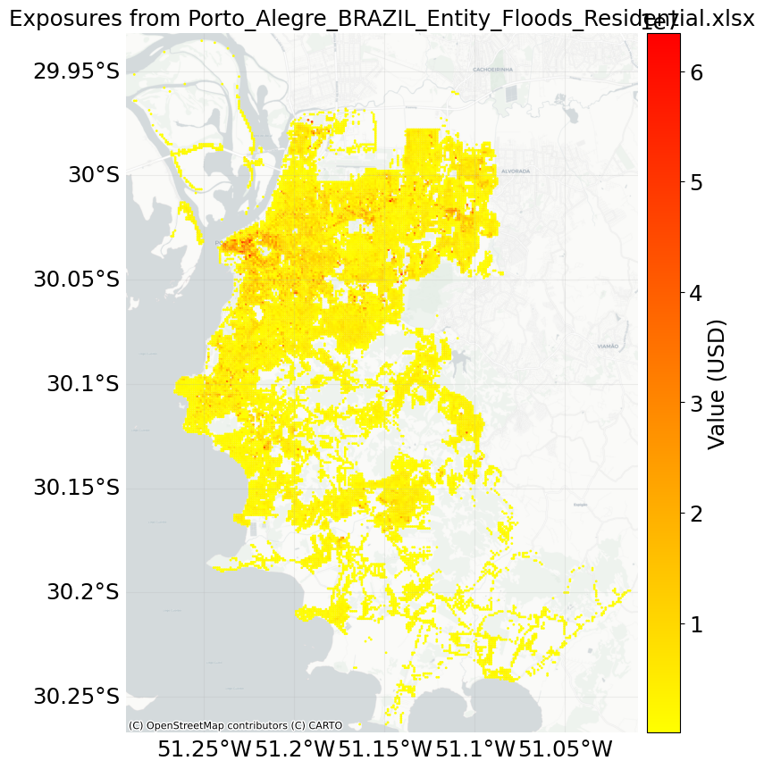

png

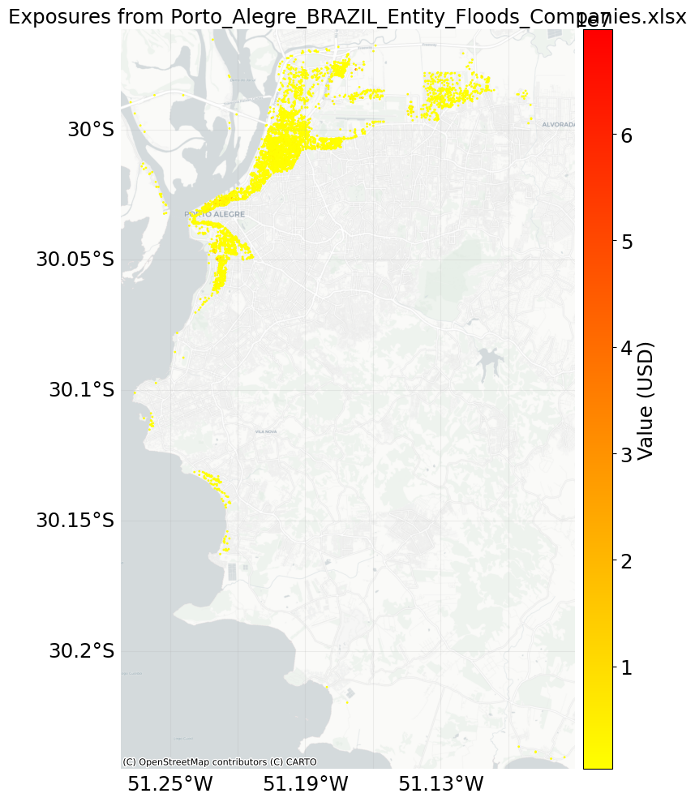

png

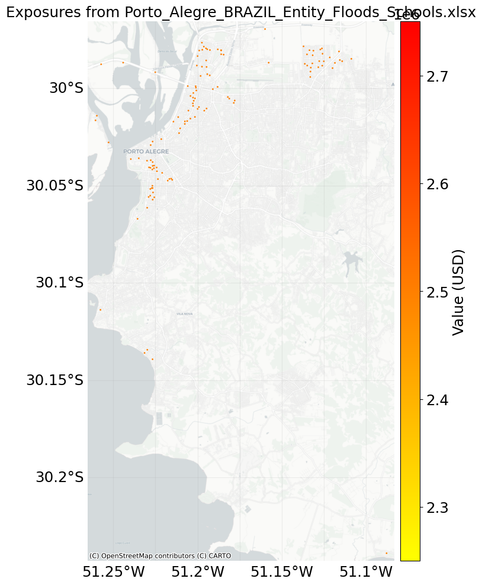

png

```python
%matplotlib inline

for entity in entity_list:
    entity.exposures.plot_basemap(
        title=entity.exposures.description,
        ignore_zero=True,       # Whether to plot points with zero value
        buffer=500,              # Add a buffer around the points to show a larger map region (measured in meters)
        s=1,                     # The size of point markers on the plot
        zoom=13,                 # The detail level of the map. 6 is good for a large country. 8 is good for a state or region. 13 for a city. 15 for a municipality.
        pop_name=False,          # Add the names of populated places to the map – often not necessary when you have a basemap
        vmax=None,               # Set the maximum value for the colour scale – use this if you want a consistent scheme across multiple plots.
        cmap="autumn_r",         # Colour scheme to use for the points. See https://matplotlib.org/stable/tutorials/colors/colormaps.html for options.
        figsize=(8, 10)         # Dimensions of the output figure
    )
```

### 5.1.3 Plot impact functions

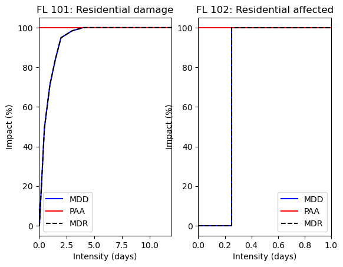

png

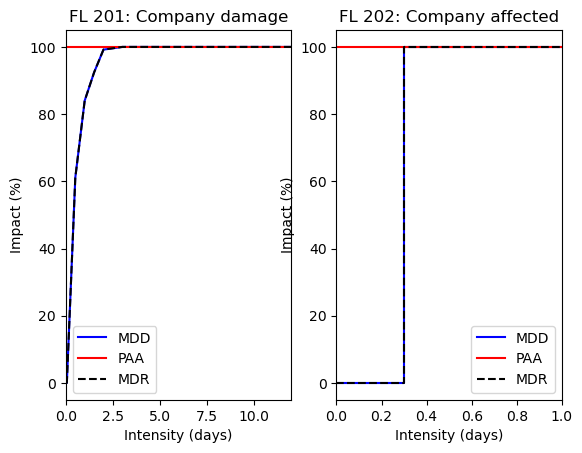

png

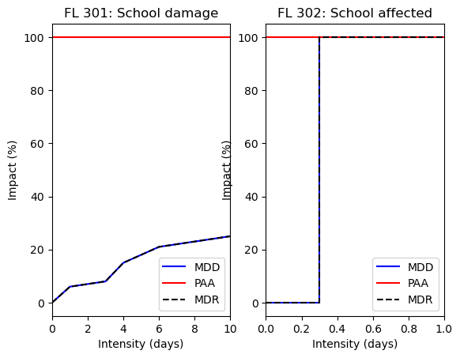

png

```python
for entity in entity_list:
    entity.impact_funcs.plot()
```

### 5.1.4 Hazard

```python
import copy
import numpy as np
from climada.hazard import Hazard

# Read in the hazard data
haz = Hazard.from_raster(
    files_intensity = haz_filepath,
    attrs={
        'unit': 'days',
        'event_name': ['2024 Flood'],     # We can optionally name the events
        'frequency': np.array([1])                  # For a historic event reconstruction we set the frequency to 1: there is no probabilistic analysis to do here
    },
    haz_type='FL',
    window=None,          # Only read a window from the raster datasets, provided as a rasterio.windows.Windows object
    geometry=None,        # Only read within a given geometry, provided as a list of shapely.geometry objects
)
```

```
2026-06-11 18:06:59,511 - climada.util.coordinates - INFO - Reading ../data/hazard/Brazil_Porto_Alegre_2024_duration.tif
2026-06-11 18:07:03,503 - climada.util.coordinates - INFO - Reading ../data/hazard/Brazil_Porto_Alegre_2024_duration.tif
```

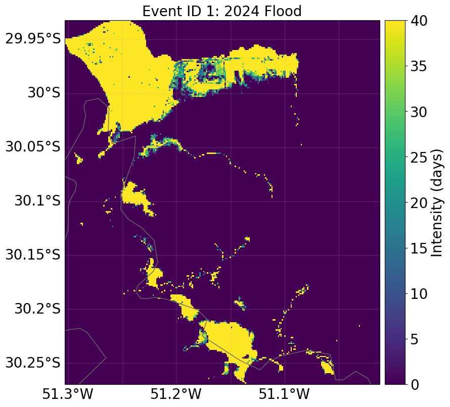

png

```python
# Plot the event
_ = haz.plot_intensity(event=1, vmax=40)
```

### 5.1.5 Map Hazard centroids to Exposure points

When CLIMADA is given a hazard and an exposure dataset it has to infer the intensity of the hazard at every exposure point. Often the hazard centroids and the exposure locations do not line up exactly. In these cases, CLIMADA finds the closest hazard centroid for each exposure, within a certain maximum search distance, set by a `threshold` parameter (or estimated by the model if not provided).

The hazard in this dataset is on a regular grid, and so CLIMADA is able to choose a distance threshold and map to the nearest centroids without difficulty.

```python
for entity in entity_list:
    entity.exposures.assign_centroids(hazard=haz, overwrite=True)
```

```
2026-06-11 18:17:00,154 - climada.entity.exposures.base - INFO - Matching 20187 exposures with 1354664 centroids.
2026-06-11 18:17:02,671 - climada.util.coordinates - INFO - No exact centroid match found. Reprojecting coordinates to nearest neighbor closer than the threshold = 0.0005387914992240894 degree
2026-06-11 18:17:03,409 - climada.entity.exposures.base - INFO - Matching 4366 exposures with 1354664 centroids.
2026-06-11 18:17:05,241 - climada.util.coordinates - INFO - No exact centroid match found. Reprojecting coordinates to nearest neighbor closer than the threshold = 0.0005387914992240894 degree
2026-06-11 18:17:05,779 - climada.entity.exposures.base - INFO - Matching 122 exposures with 1354664 centroids.
2026-06-11 18:17:08,139 - climada.util.coordinates - INFO - No exact centroid match found. Reprojecting coordinates to nearest neighbor closer than the threshold = 0.0005387914992240894 degree
```

## 5.2 Calculate risk

With all these ingredients we can run risk calculations using CLIMADA’s `ImpactCalc` class.

Each Entity file contains two impact functions: a curve for economic loss, and a step function to find affected locations. We will run both analyses.

We start by writing a method that changes the impact function assigned to the Exposures in the Entity file so that we can easily switch between impact functions:

```python
# Method to change the impact function assigned to the Exposures
def change_entity_exposure_impf(entity, new_impf_id):
    new_gdf = copy.deepcopy(entity.exposures.gdf)
    new_gdf["impf_id"] = new_impf_id
    entity.exposures.set_gdf(new_gdf)
    return entity
```

```python
from climada.engine import ImpactCalc, ImpactFreqCurve

# ----------------------------------------
# Impact: economic impacts on residences
# ----------------------------------------

# The ImpactCalc class sets up the calculation
imp_calc_residences_economic = ImpactCalc(
    exposures=entity_residences.exposures,
    impfset=entity_residences.impact_funcs,
    hazard=haz
)
# ...and its .impact method runs the calculation, creating an Impact object
imp_residences_economic = imp_calc_residences_economic.impact(
    save_mat=True,          # Save the impact matrix (see below). This can be large, but we want it to explore some additional calculations
    assign_centroids=False  # Don't (re)assign centroids
)


# ----------------------------------------
# Impact: affected residences
# ----------------------------------------

# Change the impact function assigned to the Exposures
entity_residences_affected = change_entity_exposure_impf(entity_residences, new_impf_id=102)

# Run the impact calculation again
imp_calc_residences_affected = ImpactCalc(
    exposures=entity_residences_affected.exposures,
    impfset=entity_residences_affected.impact_funcs,
    hazard=haz
)
imp_residences_affected = imp_calc_residences_affected.impact(
    save_mat=True,
    assign_centroids=False
)
```

```
2026-06-11 18:17:10,291 - climada.engine.impact_calc - INFO - Calculating impact for 100935 assets (>0) and 1 events.
2026-06-11 18:17:10,622 - climada.engine.impact_calc - INFO - Calculating impact for 100935 assets (>0) and 1 events.
```

```python
# And we can repeat this impact calculation for companies and schools exposures:

# ----------------------------------------
# Impact: economic impacts on companies
# ----------------------------------------

imp_calc_companies_economic = ImpactCalc(
    exposures=entity_companies.exposures,
    impfset=entity_companies.impact_funcs,
    hazard=haz
)
imp_companies_economic = imp_calc_companies_economic.impact(
    save_mat=True,
    assign_centroids=False
)

# ----------------------------------------
# Impact: affected companies
# ----------------------------------------

entity_companies_affected = change_entity_exposure_impf(entity_companies, new_impf_id=202)
imp_calc_companies_affected = ImpactCalc(
    exposures=entity_companies_affected.exposures,
    impfset=entity_companies_affected.impact_funcs,
    hazard=haz
)
imp_companies_affected = imp_calc_companies_affected.impact(
    save_mat=True,
    assign_centroids=False
)

# ----------------------------------------
# Impact: economic impacts on schools
# ----------------------------------------

imp_calc_schools_economic = ImpactCalc(
    exposures=entity_schools.exposures,
    impfset=entity_schools.impact_funcs,
    hazard=haz
)
imp_schools_economic = imp_calc_schools_economic.impact(
    save_mat=True,
    assign_centroids=False
)

# ----------------------------------------
# Impact: affected schools
# ----------------------------------------

entity_schools_affected = change_entity_exposure_impf(entity_schools, new_impf_id=302)
imp_calc_schools_affected = ImpactCalc(
    exposures=entity_schools_affected.exposures,
    impfset=entity_schools_affected.impact_funcs,
    hazard=haz
)
imp_schools_affected = imp_calc_schools_affected.impact(
    save_mat=True,
    assign_centroids=False
)
```

```
2026-06-11 18:17:11,061 - climada.engine.impact_calc - INFO - Calculating impact for 21830 assets (>0) and 1 events.
2026-06-11 18:17:11,116 - climada.engine.impact_calc - INFO - Calculating impact for 21830 assets (>0) and 1 events.
2026-06-11 18:17:11,172 - climada.engine.impact_calc - INFO - Calculating impact for 610 assets (>0) and 1 events.
2026-06-11 18:17:11,215 - climada.engine.impact_calc - INFO - Calculating impact for 610 assets (>0) and 1 events.
```

The Impact object has properties and methods that support you in creating risk statistics.

At the core of it is the impact matrix, which is a sparse matrix with dimensions (number of events) x (number of exposure points). It gives the calculated impact of each event at each point of exposure.

We explore this for the economic impacts we’ve calculated:

```python
import matplotlib.pyplot as plt

for imp, asset_name in zip([imp_residences_economic, imp_companies_economic, imp_schools_economic], entity_names):
    print("\n" + asset_name.upper())
    print(f"Number of exposures: {len(imp.eai_exp):,}")
    print(f"Number of events: {len(imp.event_id)}")
    print(f"Size of impact matrix: {imp.imp_mat.shape}")

    # Summing the impact across all exposed points gives us the total impact per event. This is calculated during the impact calculation and stored in the `.at_event` attribute.
    print("Total impact per event:")
    print([f'{event_name}: {impact:,.0f} {imp.unit}' for event_name, impact in zip(imp.event_name, imp.at_event)])

    # Combining the event-wise impacts with the events' frequencies let us calculate the average annual loss (AAL). This is stored in the `.aal_agg` attribute.
    # For a single event with a frequency of 1, the AAL is the same as the total impact.
    print(f"Average annual impact (AAI, or AAL) per event: {imp.aai_agg:,.0f} {imp.unit}")
```

```
RESIDENCES (ECONOMIC IMPACT)
Number of exposures: 20,187
Number of events: 1
Size of impact matrix: (1, 20187)
Total impact per event:
['2024 Flood: 7,646,578,998 USD']
Average annual impact (AAI, or AAL) per event: 7,646,578,998 USD

COMPANIES (ECONOMIC IMPACT)
Number of exposures: 4,366
Number of events: 1
Size of impact matrix: (1, 4366)
Total impact per event:
['2024 Flood: 1,489,331,376 USD']
Average annual impact (AAI, or AAL) per event: 1,489,331,376 USD

SCHOOLS (ECONOMIC IMPACT)
Number of exposures: 122
Number of events: 1
Size of impact matrix: (1, 122)
Total impact per event:
['2024 Flood: 45,750,000 USD']
Average annual impact (AAI, or AAL) per event: 45,750,000 USD
```

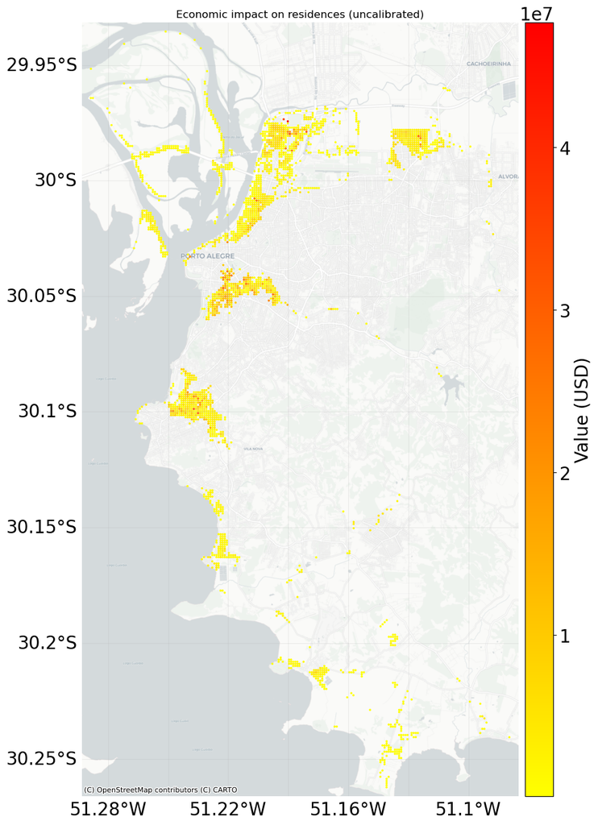

png

[figure not shown]

png

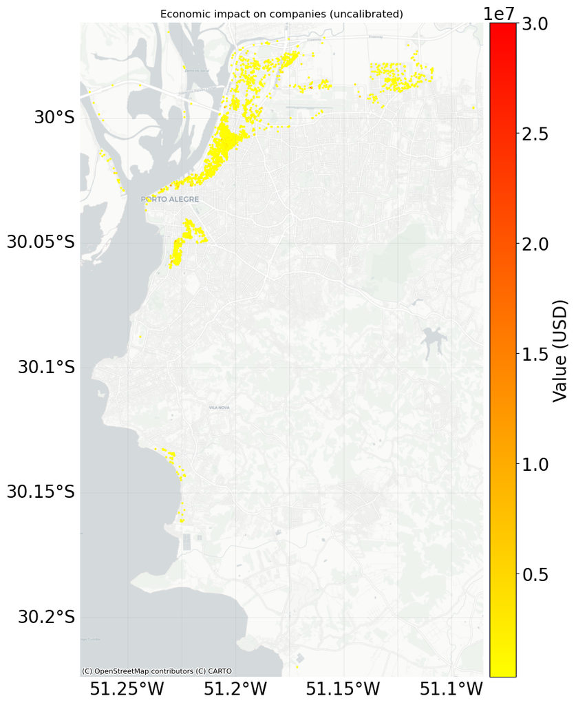

png

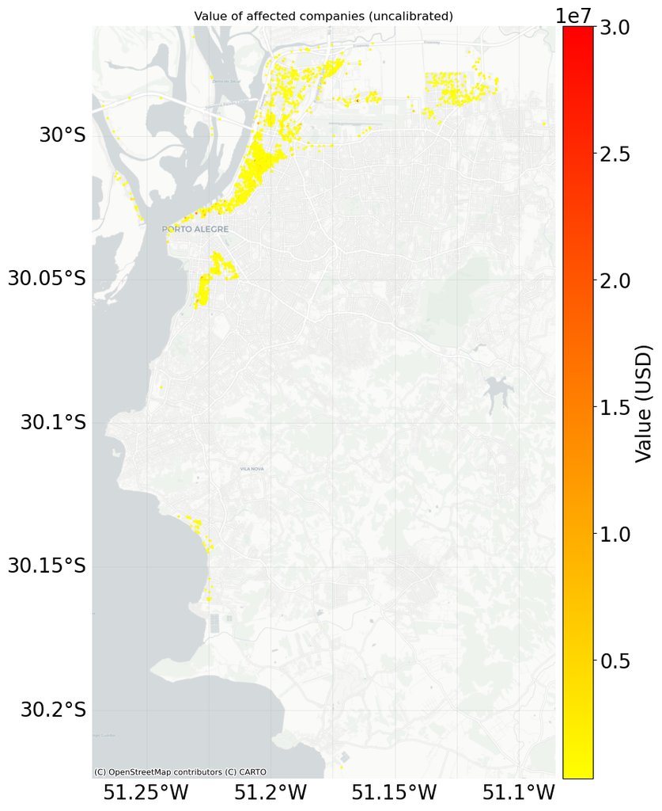

png

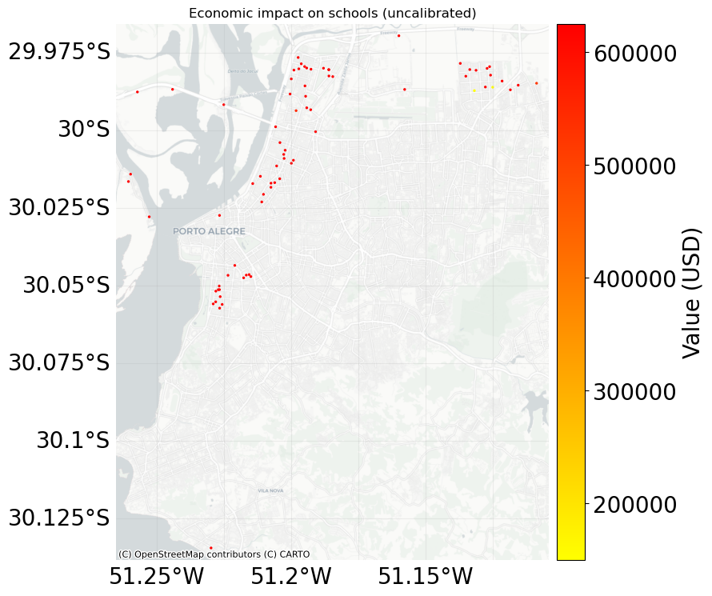

png

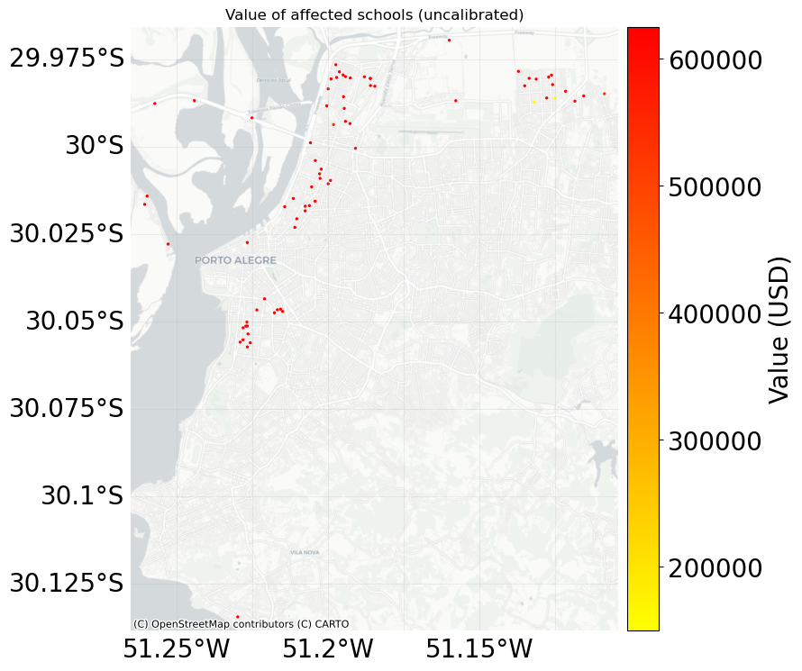

png

```python
import contextily as ctx

def plot_event_impact(imp, title):
    axis = imp.plot_basemap_eai_exposure(
        ignore_zero=True,                   # Don't plot locations with zero impacts
        pop_name=False,                     # Don't plot place names
        buffer=500,                         # Add spatial buffers to the map (in the CRS coordinate units)
        s=2,                                # The size of point markers on the plot
        zoom=13,                            # Level of detail to add to the basemap
        url=ctx.providers.CartoDB.Positron, # Basemap provider
        cmap="autumn_r",                    # Colour scheme to use for the points. See https://matplotlib.org/stable/tutorials/colors/colormaps.html for options.
    )
    axis.set_title(title)
    return axis

# We can map the event impacts by individual exposure point:
_ = plot_event_impact(imp_residences_economic, title="Economic impact on residences (uncalibrated)")
_ = plot_event_impact(imp_residences_affected, title="Value of affected residences (uncalibrated)")

_ = plot_event_impact(imp_companies_economic, title="Economic impact on companies (uncalibrated)")
_ = plot_event_impact(imp_companies_affected, title="Value of affected companies (uncalibrated)")

_ = plot_event_impact(imp_schools_economic, title="Economic impact on schools (uncalibrated)")
_ = plot_event_impact(imp_schools_affected, title="Value of affected schools (uncalibrated)")

# Note: there are also methods to plot hexbin and raster plots (as with Exposures)
```

## 5.3 Assets affected

What if we want to count the number of assets affected or the number damaged according to a particular thresholds? CLIMADA offers a simple way to do this when there is a single event in our Hazard object:

```python
# To get a broad sense of the value of exposures that are affected by any hazard (across all events), the Exposures'
# `affected_total_value` attribute is helpful:
affected_value = entity_residences.exposures.affected_total_value(
    hazard=haz,
    threshold_affected=0,
    overwrite_assigned_centroids=False
)
affected_households = affected_value / RESIDENCE_VALUE_USD
print(f"\nTotal value of all exposures: {entity_residences.exposures.value.sum():,.0f} USD")
print(f"Total value of affected exposures: {affected_value:,.0f} USD")
print(f"\nTotal number of all households: {entity_residences.exposures.value.sum() / RESIDENCE_VALUE_USD:,.0f}")
print(f"Total number of affected households: {affected_households:,.0f}")
```

```
2026-06-11 18:17:49,705 - climada.entity.exposures.base - INFO - Exposures matching centroids already found for FL

Total value of all exposures: 69,311,916,748 USD
Total value of affected exposures: 7,667,840,900 USD

Total number of all households: 184,696
Total number of affected households: 20,433
```

# 6 Observations

We have collected loss observations for the 2024 Porto Alegre floods from different sources. These will be used to calibrate the model.

The observations contain different measures of impact: both affected and financial impact.

```python
from pathlib import Path

# -----------------------------------------------
# Set up paths to data
# -----------------------------------------------

OBSERVATIONS_DIR = "../data/observations/"
OBSERVATIONS_FILE = "observations_2024.csv"
observations_filepath = Path(OBSERVATIONS_DIR) / OBSERVATIONS_FILE
```

```python
import pandas as pd
import numpy as np
from IPython.display import display

# -----------------------------------------------
# Read and print the observations
# -----------------------------------------------

obs = pd.read_csv(observations_filepath)

print("Observations: affected")
obs_affected = obs[obs['Impact type'] == 'Affected']
display(obs_affected)

print("Observations: economic loss")
obs_loss = obs[obs['Impact type'] == 'Economic loss']
display(obs_loss)
```

```
Observations: affected
```

|  | Asset type | Impact type | Units | Value | Note | Source | URL |
| --- | --- | --- | --- | --- | --- | --- | --- |
| 0 | Residential | Affected | Buildings | 39422 | NaN | Porto Alegre | https://gis-smamus.portoalegre.rs.gov.br/porta… |
| 1 | Schools | Affected | Schools | 160 | NaN | Porto Alegre | https://gis-smamus.portoalegre.rs.gov.br/porta… |
| 2 | Business: All | Affected | Businesses | 65528 | Sum of Commercial, Industrial, Tourism & Resta… | Porto Alegre | https://gis-smamus.portoalegre.rs.gov.br/porta… |
| 3 | Business: Commercial | Affected | Businesses | 18994 | NaN | Porto Alegre | https://gis-smamus.portoalegre.rs.gov.br/porta… |
| 4 | Business: Industrial | Affected | Businesses | 6442 | NaN | Porto Alegre | https://gis-smamus.portoalegre.rs.gov.br/porta… |
| 5 | Business: Tourism & Restaurants | Affected | Businesses | 7628 | NaN | Porto Alegre | https://gis-smamus.portoalegre.rs.gov.br/porta… |
| 6 | Business: Other | Affected | Businesses | 32464 | NaN | Porto Alegre | https://gis-smamus.portoalegre.rs.gov.br/porta… |
| 7 | People | Affected | People | 160210 | NaN | Porto Alegre | https://gis-smamus.portoalegre.rs.gov.br/porta… |

```
Observations: economic loss
```

[output not shown]

# 7 Calibration: Schools

## 7.1 Overview

Calibration is often the trickiest part of any risk analysis. The goal of a CLIMADA calibration is to choose an impact function (or functions) that can best reproduce observations from previous events plus any other risk data you have.

We recommend always calibrating your risk model, even if you’ve had success with a particular impact function in the past. This is because

- Impact functions from the literature were almost always designed for different hazard models, different exposure data, and different contexts. They aren’t transferrable to new contexts right out of the box.
- Impact functions change a lot with the resolution of your data.
- There are often biases or in your particular hazard or exposure datasets.
- Each study has its own context: there are always unmodelled, local conditions that can affect impacts.

In general calibrations need to be done for every combination of hazard type and exposure type that you are modelling. However, you will often find that one calibration can inform others – e.g. if you don’t have many observations on damages to businesses in your study area, but you have information on damages to housing, and you know that your first-guess impact functions needed to be adjusted down, it’s reasonable to assume you’ll want to make a similar adjustment to the first-guess impact function for businesses.

Calibrations are usually done by one of

- **Manual calibration:** taking a first-guess impact function and manually adjusting it, repeating the risk calculation, comparing it to your observations, and repeating this until you are satisfied with the outputs.
- **Automated calibration:** specifying a family of impact functions, and using software to find the ‘best’ impact function within that family, according to some cost function that you specify.
- **Some combination of the both!** Where you get a sense of the kind of impact functions that work in your study, and then refine.

The approach that works best for you will depend on the number of observations that you’re fitting to, other constraints in what you consider to be an acceptable solution, the complexity of code that you’re prepared to write, and the time you have available. With approach (2) there is no limit to the complexity of algorithms you can design to search parameter spaces and optimise within constraints. See for example the new [Calibration module](https://climada-python.readthedocs.io/en/v6.1.0/user-guide/climada_util_calibrate.html) within CLIMADA, designed (for now) for calibrations where you are modelling a set of events where each has an observed loss.

**Tips:**

- Before you start calibrating get an understanding of your data. Ask yourself some of the following:
  - What is the rough shape of the impact function you are creating? Do impacts increase slowly or quickly with the hazard? What would the maximum impact be? What shape does the curve take?
  - In your model, what range of hazard value intensities affect the assets that you’re modelling? Your function should be defined across this range. (Check in the data – you are creating an impact function for the hazard that you have, not the hazard that you imagine.)
  - Are your losses driven by small impacts at lots of locations, or large impacts at a few locations? This will tell you which part of the curve to focus on.
  - Are historical losses more from large, rare events, or from more frequent events that occur e.g. every few years? This will tell you which events to focus on getting right.
  - What functions and functional forms have been used elsewhere in the literature and are they appropriate?
- The impact of zero hazard should usually be zero. If this is not the case (e.g. with temperature or drought data), we recommend transforming or masking the hazard (e.g. setting all values to zero below some threshold at which impacts start) so that 0 hazard has zero impact. This greatly speeds up the calculations and avoids unexpected bugs.
- Make sure that you are calculating something represented by your summary statistics, or something that is close. For example:
  - Make sure the area you are modelling matches the area that your observations apply to (Ica is both a city and a Departement in Peru!).
  - Make sure the hazard data represents the processes you care about (a river flood model will struggle to reproduce flash flood losses, a drought model will struggle to reproduce heatwave losses).
- In some calibrations you will want to go beyond just the impact function, and will decide to adjust other parts of the risk calculation. For example:
  - You may want to apply bias corrections to the hazard data (e.g. corrections to flood data based on gauge histories, corrections to rainfall intensities based on an observational dataset)
  - If you are consistently getting high or low losses, check if your exposure values could be biased low (e.g. sometimes building replacement costs are more than the building value (but less than the value of the building + land, take note of what your value date represents!)). There may be a reason to scale the values of Exposures
  - You may have knowledge about something the model represents poorly: e.g. an area that is well-defended against floods and which you may choose to mask from the hazard, or a new neighborhood or piece of infrastructure not in the Exposure data

### 7.1.1 Automated calibration to multiple observations

In this notebook we explore simple parameter search routines designed to help choose appropriate impact functions for schools in Porto Alegre.

In this calculation, we will

- Read in and visualize the individual components of risk
- Write reusable methods to run the risk calculation and to compare the results to the observations
- Define a cost function to quantify how well the model is able to reproduce observations
- Write an optimization routine that tries to minimise this cost function over a family of impact functions. We do this for
  - Affected schools (calibrating a step function)
  - Economic losses (adjusting an existing loss curve)

```python
from pathlib import Path

# Set up paths to data
ENTITY_DIR = "../data/entity_files_uncalibrated/"
ENTITY_FILE = "Porto_Alegre_BRAZIL_Entity_Floods_Schools.xlsx"
entity_filepath = Path(ENTITY_DIR) / ENTITY_FILE

CALIBRATED_ENTITY_DIR = "../data/entity_files_calibrated/"
CALIBRATED_ENTITY_FILE = "Porto_Alegre_BRAZIL_Entity_Floods_Schools_calibrated.xlsx"
calibrated_entity_filepath = Path(CALIBRATED_ENTITY_DIR) / CALIBRATED_ENTITY_FILE

HAZARD_DIR = "../data/hazard/"
HAZARD_FILE = "Brazil_Porto_Alegre_2024_duration.tif"
haz_filepath = Path(HAZARD_DIR) / HAZARD_FILE

OBSERVATIONS_DIR = "../data/observations/"
OBSERVATIONS_FILE = "observations_2024.csv"
observations_filepath = Path(OBSERVATIONS_DIR) / OBSERVATIONS_FILE
```

## 7.2 Load the components of risk

During the calibration we will be running risk calculations and plotting outputs repeatedly. To do this, we wrap the functionality of the central loop in reusable methods.

### 7.2.1 Load the Entity file

```python
import copy
from climada.entity import Entity

impf_column = "impf_FL"   # Impact function column in the assets table
impf_id_loss = 301        # ID of the impact function for economic loss that we're calibrating
impf_id_affected = 302    # ID of the impact function for affected schools that we're calibrating

# Read the Entity file
def read_entity(path, value_column):
    entity = Entity.from_excel(path)

    # In one part of the calibration, we calibrate against _number of buildings_ that are affected or destroyed
    # In the Entity file the 'value' column contains building value information in USD, and the e.g. 'housing_count'
    # column contains the number of buildings. So we rename the columns so that the 'value' column contains the
    # information we want.
    if value_column == 'value':
        return entity
    new_gdf = entity.exposures.gdf.copy()
    new_gdf["value"] = new_gdf[value_column]
    entity.exposures.set_gdf(new_gdf)
    return entity

# Read the Entity file for USD value
entity_usd = read_entity(entity_filepath, value_column='value')
entity_usd.exposures.ref_year = 2025
entity_usd.exposures.value_unit = "USD"
entity_usd.exposures.description = "Economic value"

# Read the Entity file for housing count
entity_count = read_entity(entity_filepath, value_column='count')
entity_count.exposures.ref_year = 2025
entity_count.exposures.value_unit = "number of schools"
entity_count.exposures.description = "Number of schools"
```

#### 7.2.1.1 Plot exposures

The Schools Exposures aren’t a complete dataset of Porto Alegre schools: these are the ones that are considered to be affected, roughly overlapping with the hazard footprint.

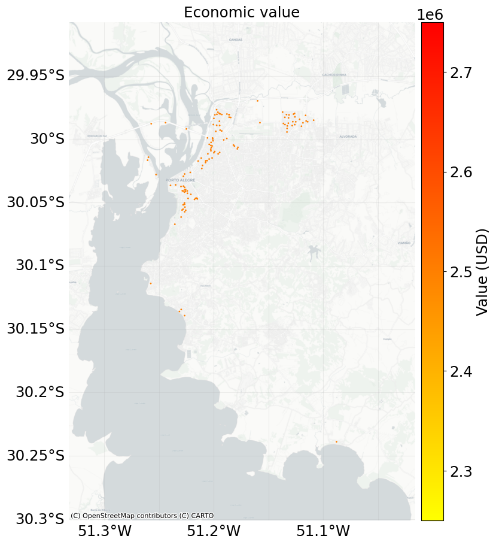

png

```python
# Plot the exposures
_ = entity_usd.exposures.plot_basemap(
        ignore_zero=True,        # Whether to plot points with zero value
        buffer=8000,             # Add a buffer around the points to show a larger map region (measured in meters)
        s=1,                     # The size of point markers on the plot
        zoom=13,                 # The detail level of the map. 6 is good for a large country. 8 is good for a state or region. 13 for a city. 15 for a municipality.
        pop_name=False,          # Add the names of populated places to the map – often not necessary when you have a basemap
        vmax=None,               # Set the maximum value for the colour scale – use this if you want a consistent scheme across multiple plots.
        cmap="autumn_r",         # Colour scheme to use for the points. See https://matplotlib.org/stable/tutorials/colors/colormaps.html for options.
        figsize=(8, 10)          # Dimensions of the output figure
    )
```

#### 7.2.1.2 Plot impact functions

There are a few ways to approach a calibration like this, depending on the statistics you want to produce and the purposes of the calibration.

Our approach is going to look at two flood damage curves, each describing a different risk metric: - A depth-damage curve that estimates the % loss at a point of exposure. - An ‘affected’ step-function. This gives the threshold at which a school is considered to be affected by the flood

We have first-guess versions of these impact functions in the Entity file:

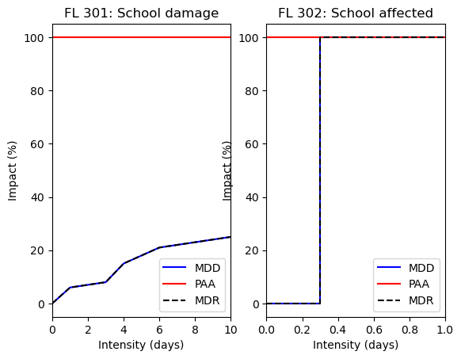

png

```python
# Plot the impact functions
_ = entity_usd.impact_funcs.plot()
```

### 7.2.2 Load Hazard data

The Hazard data is a single event footprint in a .tif file containing information on flood duration in days. We provide additional metadata to CLIMADA as we read this in.

```python
import numpy as np
from climada.hazard import Hazard

# Read in the hazard data
haz = Hazard.from_raster(
    files_intensity = haz_filepath,
    attrs={
        'unit': 'days',
        'event_name': ['2024 Flood'],     # We can optionally name the events
        'frequency': np.array([1])        # For a historic event reconstruction we set the frequency to 1: there is no probabilistic analysis to do here
    },
    haz_type='FL',
    window=None,          # Only read a window from the raster datasets, provided as a rasterio.windows.Windows object
    geometry=None,        # Only read within a given geometry, provided as a list of shapely.geometry objects
)
```

```
2026-06-11 18:06:20,402 - climada.util.coordinates - INFO - Reading ../data/hazard/Brazil_Porto_Alegre_2024_duration.tif
2026-06-11 18:06:25,742 - climada.util.coordinates - INFO - Reading ../data/hazard/Brazil_Porto_Alegre_2024_duration.tif
```

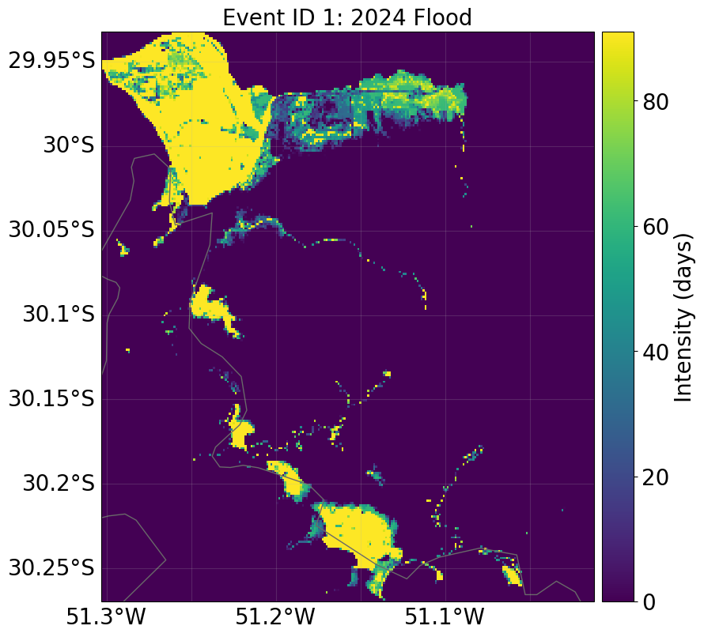

png

```python
# Plot the maximum intensity across all events
_ = haz.plot_intensity(event=1)
```

```python
# Assign hazard centroids to the exposures
entity_usd.exposures.assign_centroids(hazard=haz, overwrite=True)
entity_count.exposures.assign_centroids(hazard=haz, overwrite=True)

assert entity_usd.exposures.gdf['centr_FL'].isna().sum() == 0, "Some exposures do not have an assigned hazard centroid."
assert entity_count.exposures.gdf['centr_FL'].isna().sum() == 0, "Some exposures do not have an assigned hazard centroid."
```

```
2026-06-11 18:16:56,976 - climada.entity.exposures.base - INFO - Matching 122 exposures with 1354664 centroids.
2026-06-11 18:16:59,452 - climada.util.coordinates - INFO - No exact centroid match found. Reprojecting coordinates to nearest neighbor closer than the threshold = 0.0005387914992240894 degree
2026-06-11 18:17:00,033 - climada.entity.exposures.base - INFO - Matching 122 exposures with 1354664 centroids.
2026-06-11 18:17:00,943 - climada.util.coordinates - INFO - No exact centroid match found. Reprojecting coordinates to nearest neighbor closer than the threshold = 0.0005387914992240894 degree
```

### 7.2.3 Load observations

We read in the observations that we have for impacts to schools.

We also compare them to the Exposures data we have: the number of reported schools impacted is larger than the number of schools in our dataset, and this will be important in the calibration, and the reported loss is also very high.

```python
import pandas as pd

BRL_to_USD = 0.18  # 2024 Exchange rate

obs = pd.read_csv(observations_filepath)

obs_schools = obs[obs["Asset type"] == "Schools"]

obs_affected_2024 = obs_schools[
    (obs_schools['Impact type'] == 'Affected') &
    (obs_schools['Source'] == 'Porto Alegre')
]['Value']
assert len(obs_affected_2024) == 1, "There should be exactly one observation of affected schools."
obs_affected_2024 = obs_affected_2024.values[0]

obs_loss_2024 = obs_schools[
    (obs_schools['Impact type'] == 'Economic loss') &
    (obs_schools['Source'] == 'IDB')
]['Value']
assert len(obs_loss_2024) == 1, "There should be exactly one observation of economic loss for schools."
obs_loss_2024 = obs_loss_2024.values[0] * BRL_to_USD

print(f"Observed number of affected schools: {obs_affected_2024}")
print(f"Total number of schools in our Exposures: {entity_count.exposures.gdf['value'].sum()}")

print(f"\nObserved economic loss for schools (in USD): {obs_loss_2024:,.0f}")
print(f"Total value of schools in our Exposures (in USD): {entity_usd.exposures.gdf['value'].sum():,.0f}")
```

```
Observed number of affected schools: 160
Total number of schools in our Exposures: 122

Observed economic loss for schools (in USD): 121,867,740
Total value of schools in our Exposures (in USD): 305,000,000
```

## 7.3 Write methods for reusable risk calculations

We calibrate the impact functions by running risk calculations, adjusting the impact functions, and attempting to reproduce the observations that we have.

```python
import matplotlib.pyplot as plt
import contextily as ctx
from climada.entity import ImpactFunc, ImpactFuncSet
from climada.engine import ImpactCalc, ImpactFreqCurve, Impact

# ----------------------------------------
# Methods for risk calculations
# ----------------------------------------

# Run a risk calculation and extract impact statistics at our chosen return periods
def risk_calc(entity, hazard):
    entity.exposures.assign_centroids(hazard=hazard, overwrite=False)
    imp = ImpactCalc(entity.exposures, entity.impact_funcs, hazard).impact(save_mat=False, assign_centroids=False)
    loss_2024 = imp.at_event[0]
    return imp, loss_2024


# Define a cost function that says how 'close' our modelled outputs are to the observations
# Normally this would be a root mean squared error or similar. But since we only have one observation, we can just take
# the % difference between the observation and the modelled value.
def cost_function(modelled, observed):
    cost = np.abs((modelled - observed) / observed) * 100
    return cost

# Swap a new impact function into an Entity file
# and assign its ID for all exposure points
def replace_impact_function(entity, new_impf):
    entity_new = copy.deepcopy(entity)
    entity_new.impact_funcs = ImpactFuncSet([new_impf])
    gdf_new = copy.deepcopy(entity_new.exposures.gdf)
    gdf_new['impf_FL'] = new_impf.id
    entity_new.exposures.set_gdf(gdf_new)
    return entity_new


# Map impacts
def plot_map(imp: Impact, title: str=None):
    axis = imp.plot_basemap_eai_exposure(
        ignore_zero=True,  # Only show at-risk assets
        buffer=500,
        s=2,
        zoom=14,
        url=ctx.providers.CartoDB.Positron,
        cmap="autumn_r",
        figsize=(6, 10)
    )
    if title is not None:
        axis.set_title(title)
    plt.show()
    plt.close(axis.figure)
```

## 7.4 Affected schools calibration: step function

We start by calibrating functions for affected schools. ‘Affected’ is considered to be a binary here – a school at an exposure point are affected or it isn’t.

This is modelled with a step function. Step functions are the simplest to calibrate: they start at zero impact and jump to 100% – the only thing that has to be determined is the threshold at which this happens.

We already know that more schools are reported affected than we have in our Exposures, so we can expect that the step will be very low!

CLIMADA has a method for building new step impact functions – `ImpactFunc.from_step_impf` and we will use this to find the one that best explains the data that we have.

### 7.4.1 First-guess analysis

Our Entity file has a first-guess impact function for affected schools. This is what we’ll be improving on:

```python
# Modify our Entity to use the default 'affected' impact function
default_impf_affected = entity_count.impact_funcs.get_func(haz_type='FL', fun_id=impf_id_affected)
entity_affected = replace_impact_function(entity_count, default_impf_affected)

# Calculate risk
imp_affected, modelled_affected = risk_calc(entity_affected, haz)
cost = cost_function(modelled_affected, obs_affected_2024)

# Create plots
entity_affected.impact_funcs.plot()
print(f"\nModelled affected schools: {modelled_affected:.0f}")
print(f"Target affected schools: {obs_affected_2024:.0f}")
print(f"Cost: {cost:.2f}% difference")
```

```
2026-06-11 18:17:02,601 - climada.entity.exposures.base - INFO - Exposures matching centroids already found for FL
2026-06-11 18:17:02,639 - climada.engine.impact_calc - INFO - Calculating impact for 610 assets (>0) and 1 events.

Modelled affected schools: 75
Target affected schools: 160
Cost: 53.12% difference
```

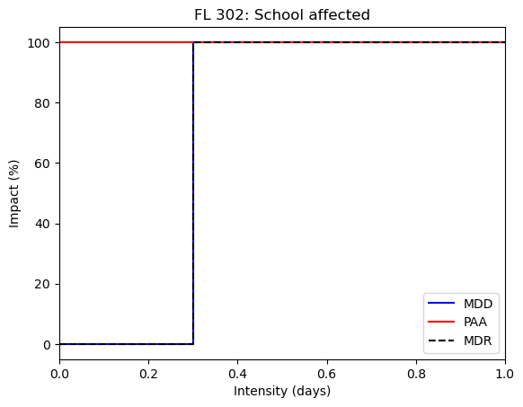

png

The intial plots show us a few things that can guide the calibration:

- We’re improving on a first-guess step function where a school is affected if it is flooded for 0.3 days or more
- This underestimates the reported impacts, which we expected